# Modelo Binomial

Dario Bacchini

Consideremos la siguiente información:

```r
r <- 0.08 # Efectiva para un período
S <- tibble(S0 = c(10, NA),
            S1 = c(12,  9))
p_up <- 0.95
paste0("La probabilidad del nodo 'up' es: ", p_up)
```

```
## [1] "La probabilidad del nodo 'up' es: 0.95"
```

```r
S %>% flextable()
```

| S0 | S1 |
| --- | --- |
| 10 | 12 |
|  | 9 |

¿Cuál es el rendimiento esperado del S?

```r
E_S1 <- S$S1[1]*p_up + S$S1[2]*(1-p_up)
mu <- E_S1/S$S0[1] - 1
paste0("mu = ", scales::percent(mu))
```

```
## [1] "mu = 19%"
```

¿Cuál es el valor de S?

…

¿Cuánto vale un instrumento DERIVADO que me paga $f_u=5$ en el escenario de alza o bien $f_d=-4$ en el escenario de baja?

Valuación naive:

```r
f <- tibble(f0 = c(NA,NA),
            f1 = c( 5,-4))
f$f0[1] <- (f$f1[1]*p_up + f$f1[2]*(1-p_up))/(1+mu)
f %>% flextable()
```

| f0 | f1 |
| --- | --- |
| 3.839662 | 5 |
|  | -4 |

Valuación “teórica”:

```r
FD <- 1/(1+r) # Porque 'r' es Tasa efectiva
u <- S$S1[1]/S$S0[1]
d <- S$S1[2]/S$S0[1]
pRN <- (1/FD - d)/(u-d)
fT <- tibble(f0 = c( (f$f1[1]*pRN + f$f1[2]*(1-pRN)) * FD , NA),
             f1 = f$f1)
fT %>% flextable()
```

| f0 | f1 |
| --- | --- |
| 1.296296 | 5 |
|  | -4 |

¿Cuánto me pagan por el “derivado”?

Vendo a:

```r
f_M <- 3
paste0("Pagan ", f_M, " y esperan un valor de ", (f$f1[1]*p_up + f$f1[2]*(1-p_up)), "; es decir,",
       " el retorno esperado es: ", scales::percent((f$f1[1]*p_up + f$f1[2]*(1-p_up))/f_M-1))
```

```
## [1] "Pagan 3 y esperan un valor de 4.55; es decir, el retorno esperado es: 52%"
```

Notar que si el precio fuera otro, el rendimiento esperado cambiaría.

```
## [1] "Si pagaran 3.5 y esperan un valor de 4.55, el retorno esperado sería: 30%"
```

#### Arbitraje!

Estoy dispuesto a vender al valor de “mercado” y armo mi arbitraje:

Si vendi derivado, debo “comprar” subyacente (Nota, si delta<0, entonces sería efectivamente una venta):

```r
delta <-(f$f1[1] - f$f1[2])/(S$S1[1] - S$S1[2])
paste0("delta = ", delta)
```

```
## [1] "delta = 3"
```

```r
  Tabla <- tibble(Instrumento = c("f", "S", "B"),
                  Posición = c("vendo (short)",
                               "'Compro' delta",
                               "Compensa"),
                  Flujo_Inicial = c(+f_M,
                                    -S$S0[1]*delta,
                                    (-f_M+S$S0[1]*delta)))
Tabla %>% flextable()
```

| Instrumento | Posición | Flujo_Inicial |
| --- | --- | --- |
| f | vendo (short) | 3 |
| S | 'Compro' delta | -30 |
| B | Compensa | 27 |

Escenario UP:

```r
Tabla$UP <- c(-f$f1[1],                       #Pago Derivado
              +delta*S$S1[1],                 # Veta de subyacente comprado
              -Tabla$Flujo_Inicial[3]*1/FD    # Pago préstamo
              )
Tabla %>% flextable()
```

| Instrumento | Posición | Flujo_Inicial | UP |
| --- | --- | --- | --- |
| f | vendo (short) | 3 | -5.00 |
| S | 'Compro' delta | -30 | 36.00 |
| B | Compensa | 27 | -29.16 |

Escenario DOWN:

```r
Tabla$DOWN <- c(-f$f1[2],                       #Pago Derivado
              +delta*S$S1[2],                 # Veta de subyacente comprado
              -Tabla$Flujo_Inicial[3]*1/FD    # Pago préstamo
              )
Tabla %>% flextable()
```

| Instrumento | Posición | Flujo_Inicial | UP | DOWN |
| --- | --- | --- | --- | --- |
| f | vendo (short) | 3 | -5.00 | 4.00 |
| S | 'Compro' delta | -30 | 36.00 | 27.00 |
| B | Compensa | 27 | -29.16 | -29.16 |

```r
Totales <- Tabla %>%
  summarise(
  Instrumento = " ",
  Posición = "Total",
  Flujo_Inicial = sum(Flujo_Inicial),
  UP = sum(UP),
  DOWN = sum(DOWN)
)
Tabla <- Tabla %>%
  add_row(!!!Totales)
Tabla %>% flextable()
```

| Instrumento | Posición | Flujo_Inicial | UP | DOWN |
| --- | --- | --- | --- | --- |
| f | vendo (short) | 3 | -5.00 | 4.00 |
| S | 'Compro' delta | -30 | 36.00 | 27.00 |
| B | Compensa | 27 | -29.16 | -29.16 |
|  | Total | 0 | 1.84 | 1.84 |

Mi ganancia (ARBITRAJE; LIBRE DE RIESGO) es lo que “cobré de más” capitalizado:

```r
(f_M - fT$f0[1])*1/FD
```

```
## [1] 1.84
```

### **Ejercicio Parcial 2024.06.12**

El precio de una acción es $27.67, su volatilidad es 12% y el rendimiento esperado es 7%. La tasa libre de riesgo es 4% anual con composición continua.

```r
S = 27.67
sigma = 0.12
mu = 0.07
r = 0.04
```

**a) Construya un árbol binomial de dos pasos, con plazo total de tres meses.**

```
## [1] "Vencimiento = 0.25 años"
```

```
## [1] "u = 1.04333927094692"
```

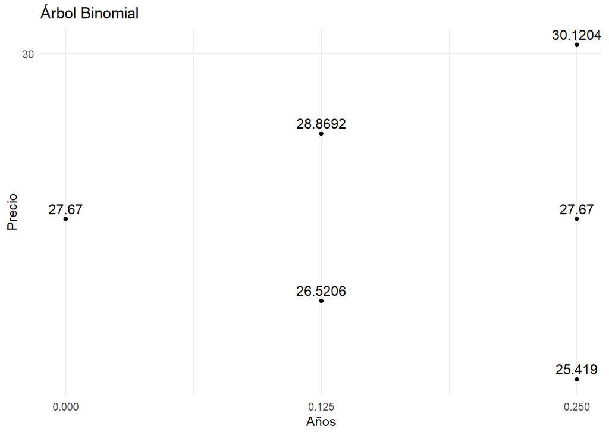

**b) Con el árbol construido en el punto a), calcula la prima de un Put Europeo con precio de ejercicio $28 y vencimiento en tres meses.**

```
## [1] "K = 28"
```

```
## [1] "PRN = 0.548450395611605"
```

```
## [1] "FD(dt) = 0.995012479192682"
```

```
## # A tibble: 3 × 3
##     pE0   pE1   pE2
##   <dbl> <dbl> <dbl>
## 1 0.683 0.148 0
## 2 0     1.34  0.330
## 3 0     0     2.58
```

```
## [1] "La prima del Put Europeo es: 0.68285109724023"
```

**c) Realice un arbitraje si el precio del Put del punto b) es $0.60. Considere solamente el camino “down-up” del precio del subyacente para ilustrar la estrategia.**

```r
pM = 0.6
```

Árbol de deltas:

```
## # A tibble: 3 × 3
##       d0     d1    d2
##    <dbl>  <dbl> <dbl>
## 1 -0.507 -0.135    NA
## 2 NA     -1        NA
## 3 NA     NA        NA
```

```
## # A tibble: 4 × 5
##   Instrumento Posición      Flujo_Inicial `t1 down` `t1 down-up`
##   <chr>       <chr>                 <dbl>     <dbl>        <dbl>
## 1 "Put"       Compro (Long)     -6   e- 1       0         0.330
## 2 "Acción"    Short delta       -1.40e+ 1     -13.1      27.7
## 3 "Bono"      Vendo              1.46e+ 1      13.1     -27.9
## 4 " "         Total             -3.33e-16       0         0.0837
```

Arbitraje a prima mercado:

```
## # A tibble: 3 × 5
##   momento      Opcion Subyacente  Bono  Total
##   <chr>         <dbl>      <dbl> <dbl>  <dbl>
## 1 t0           -0.6        -14.0  14.6 0
## 2 t1 down       0          -13.1  13.1 0
## 3 t2 down - up  0.330       27.7 -27.9 0.0837
```

```
## [1] "Arbitraje en t2 = 0.0836837646105977"
```

```
## [1] "VA arbitraje = 0.0828510972402268"
```

```
## [1] "Diferencia Prima Teórica vs Mercado = 0.0828510972402304"
```

```
## [1] "¿Es VA Arbitraje igual a Diferencia (hasta 10 decimales)? TRUE"
```

**d) Si se negocia un put americano con igual subyacente, strike y vencimiento, calcule la “prima por ejercicio anticipado”.**

```
## # A tibble: 3 × 3
##     pA0   pA1   pA2
##   <dbl> <dbl> <dbl>
## 1 0.746 0.148 0
## 2 0     1.48  0.330
## 3 0     0     2.58
```

```
## [1] "La Prima pdel Put Americano es: 0.745595753668913"
```

```
## [1] "Prima por ejercicio anticipado: 0.0627446564286821"
```